# iDEP: Investigating Differentially Expressed Genes

## If this site has contributed to your work, please cite our article:

Ge, S.X., Son, E.W. & Yao, R. iDEP: an integrated web application for differential expression and pathway analysis of RNA-Seq data. BMC Bioinformatics 19, 534 (2018). https://doi.org/10.1186/s12859-018-2486-6

## Summary

Read Counts data were analyzed using iDEP v2.4.4. The data was first filtered to remove reads below 0.5 CPM in at least 1 sample. Then the data was transformed with EdgeR using a pseudocount of 4. Missing values were imputed using geneMedian.

After mapping, there are 32833 unique genes in 158 samples. Of the 24127 genes passed filter, 24127 were converted to Ensembl/STRING gene IDs in our database. The remaining 0 genes were kept in the data using original IDs.

Differential expression analysis was performed using DESeq2 with an FDR cutoff of 0.1 and a minimum fold-change threshold of 2. Standard Wald test was used and independent filtering was enabled.

## Selected Comparison: Radiation_Dose_cGy40-Radiation_Dose_cGy0

Up-regulated genes: 1

Down-regulated genes: 6

## Top Up-regulated Genes

```r
if (!is.null(params$up_genes_table) && nrow(params$up_genes_table) > 0) {
  kbl(params$up_genes_table, escape = FALSE) %>%
    kable_classic(full_width = FALSE, html_font = "Cambria")
} else {
  print("No up-regulated genes found for this comparison.")
}
```

| Symbol | Ensembl ID | log2 FC | Adj. P-value | Description |
| --- | --- | --- | --- | --- |
| AT2G07751 AT2G07751 | AT2G07751 | 6.039 | 9.92e-02 | NADH:ubiquinone/plastoquinone oxidoreductase, chain 3 protein |

## Top Down-regulated Genes

```r
if (!is.null(params$down_genes_table) && nrow(params$down_genes_table) > 0) {
  kbl(params$down_genes_table, escape = FALSE) %>%
    kable_classic(full_width = FALSE, html_font = "Cambria")
} else {
  print("No down-regulated genes found for this comparison.")
}
```

| Symbol | Ensembl ID | log2 FC | Adj. P-value | Description |
| --- | --- | --- | --- | --- |
| SESA3 | AT4G27160 | -14.048 | 6.35e-03 | Seed storage albumin 3 |
| CRU3 | AT4G28520 | -13.753 | 1.38e-03 | Cruciferin 3 |
| CYP71A13 | AT2G30770 | -13.711 | 2.18e-08 | Cytochrome P450 family 71 polypeptide |
| AT5G01645 | AT5G01645 | -13.029 | 1.55e-03 | NcRNA |
| AT5G48940 | AT5G48940 | -2.395 | 9.07e-03 | Leucine-rich repeat transmembrane protein kinase family protein |
| BXL3 | AT5G09730 | -2.180 | 2.85e-03 | Beta-xylosidase 3 |

## DEG Heatmap

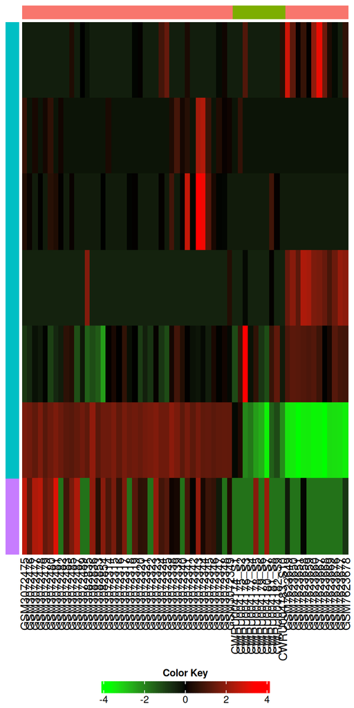

```r
if (!is.null(params$heat_data) && !is.null(params$heat_bar)) {
  heat_colors <- unlist(strsplit(params$heatmap_color_select, "-"))

  deg_heatmap(
    df = params$heat_data,
    bar = params$heat_bar,
    heatmap_color_select = heat_colors,
    cluster_rows = FALSE
  )
}
```

## Volcano Plot

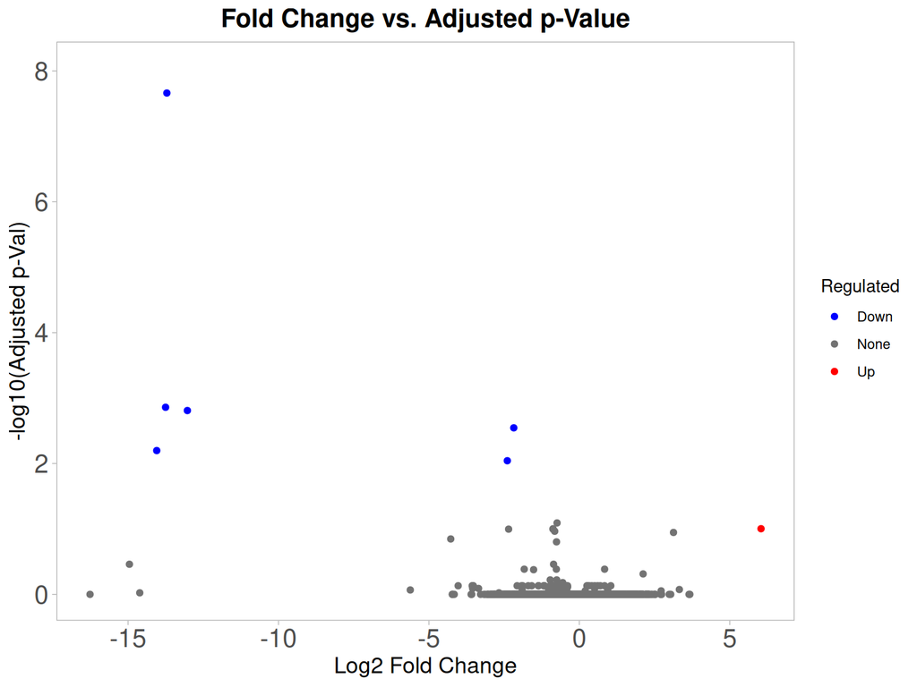

```r
if (!is.null(params$vol_data) && !is.null(params$vol_data$data)) {
  p <- plot_volcano(
    data = params$vol_data$data,
    plot_colors = params$plot_colors,
    anotate_genes = params$gene_labels_volcano
  )
  p <- refine_ggplot2(
    p = p,
    gridline = params$plot_grid_lines,
    ggplot2_theme = params$ggplot2_theme
  )
  print(p)
}
```